# ReproducibleResearch

Anna

2016年4月9日

- **`knitr` package**
  - written by YihuiXie, built into RStudio
  - support Markdown, LaTeX, HTML as documentation languages
  - Exports PDF/HTML
  - evaluates R markdown documents and return/records the results, and write out a Markdown files
  - Markdown file can then be converted into HTML using markdown package
  - solidify package converts R markdown into presentation slides
- In RStudio, create new R Markdown files by clicking New $\rightarrow$ R Markdown
  - `========` = indicates title of document (large text)
  - `$expression$` = indicates LaTeX expression/formatting
  - ``text`` = changes text to code format (typewriter font)
  - ````{r name, echo = FALSE, results = hide}...```` = R code chunk
    - `name` = name of the code chunk
    - `echo = FALSE` = turns off the echo of the R code chunk, which means display only the result
    - **Note**: by default code in code chunk is echoed = print code AND results
    - `results = hide` = hides the results from being placed in the markdown document
  - inline text computations
    - ``r` `variable`` = prints the value of that variable directly inline with the text
  - incorporating graphics
    - ````{r scatterplot, fig.height = 4, fig.width = 6} ... plot() ...```` = inserts a plot into markdown document
      - `scatterplot` = name of this code chunk (can be anything)
      - `fig.height = 4` = adjusts height of the figure, specifying this alone will produce a rectangular plot rather than a square one by default
      - `fig.width = 6` = adjusts width of the figure
    - knitr produces HTML, with the image embedded in HTML using base64 encoding
      - does not depend on external image files
      - not efficient but highly transportable
  - incorporating tables (xtable package: `install.packages("xtable")`)
    - `xtable`prints the table in html format, which is better presented than plain text normally

```r
library(datasets)
## library(xtable)
fit <- lm(Ozone ~ Wind + Temp + Solar.R, data = airquality)
## xt <- xtable(summary(fit))
## print(xt, "html")
```

- **setting global options**
  - ````{r setoptions, echo = FALSE} opts_chunk$set(echo = FALSE, results = "hide")```` = sets the default option to not print the code/results unless otherwise specified
- **common options**
  - **output**: `results = "asis"` OR `"hide"`
    - `"asis"` = output to stay in original format and not compiled into HTML
  - **output**: `echo = TRUE` OR `FALSE`
  - **figures**: `fig.height = numeric`
  - **figures**: `fig.width = numeric`
- **caching computations**
  - add argument to code chunk: `cache = TRUE`
  - computes and stores result of code the first time it is run, and calls the stored result directly from file for each subsequent call
  - useful for complex computations
  - caveats:
    - if data/code changes, you will need to re-run cached code chunks
    - dependencies not checked explicitly (changes in other parts of the code $\rightarrow$ need to re-run the cached code)
    - if code does something outside of the document (i.e. produce a png file), the operation cannot be cached
- **“Knit HTML”** button to process the document
  - alternatively, when not in RStudio, the process can be accomplished through the following

```r
library(knitr)
setwd(<working directory>)
knit2html("document.Rmd")
browseURL("document.html")
```

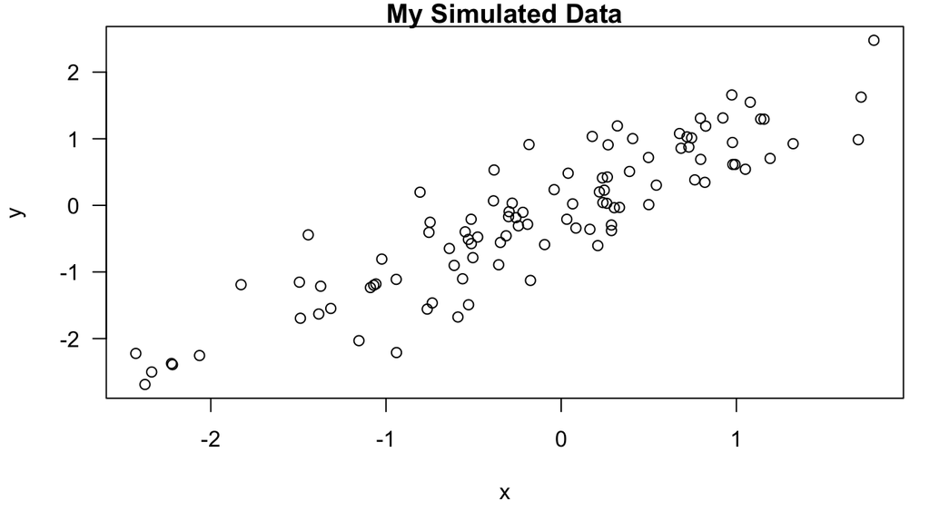

```r
##  highlight=TRUE,
x <- rnorm(100)
y <- x + rnorm(100, sd = 0.5)
par(mar = c(5,4,1,1), las=1)
plot(x, y, main="My Simulated Data")
```

The current time is Sat Apr 23 13:18:45 2016. My favorite random number is 0.0828412.